# Creating a World Cup Database

Based on one of the required projects for the freecodecamp.com Relational Database Certification, we will create a World Cup Database using Git Bash and PostgreSQL and subsequently answer some questions using the database.

## The Data

The data is fairly simple. It contains information about games played in the 2014 and 2018 FIFA World Cup's starting from Round 16 all the way up to the Final Round. Here is a preview:

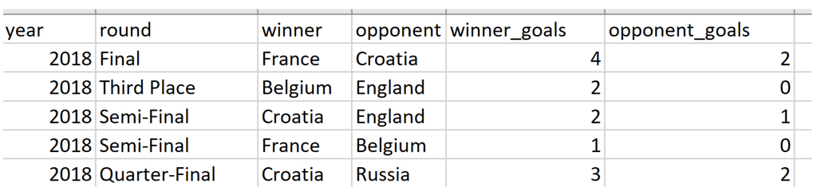

As you can see, there is a column for the round, winning team, opponent team and goals scored by each team. We will use this data to fill up our database.

## Database Structure

Before we can insert the data into our database, let's understand the schema. This database will consist of two tables: `games` and `teams`. Here is a chart showing how the tables will be organized:

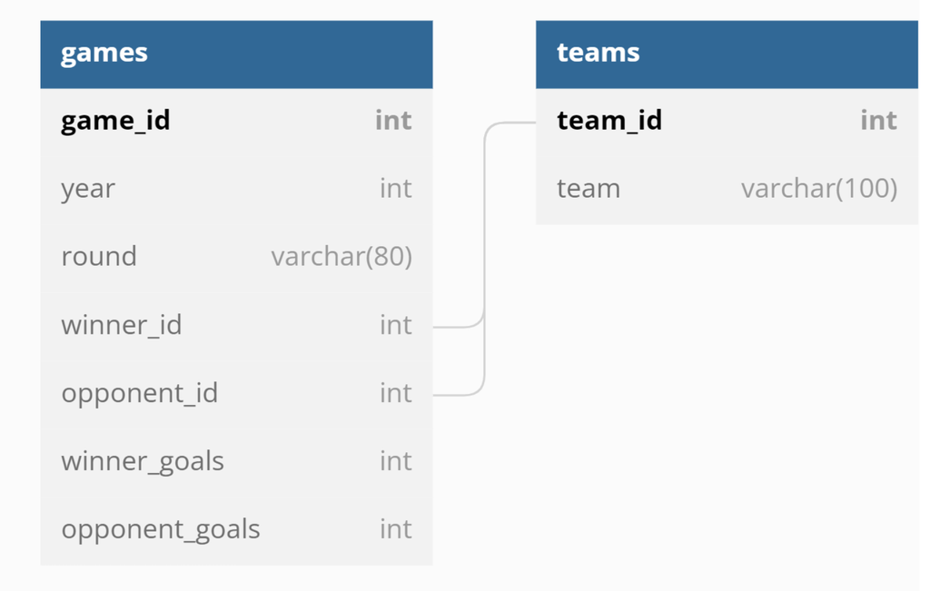

## Creating the Database

Using Git Bash, we can connect to PostgreSQL to create the `worldcup` database and the two tables within it. To connect, you have to use the following command `psql -U postgres`. Below is some of the code used for creating the database and the two tables.

```
CREATE DATABASE worldcup;

CREATE TABLE teams(
    team_id SERIAL PRIMARY KEY
    name VARCHAR(100));

CREATE TABLE games(
    game_id SERIAL PRIMARY KEY
    year INT NOT NULL
    round VARCHAR(80)
    winner_id INT NOT NULL REFERENCES teams.team_id
    opponent_id INT NOT NULL REFERENCES teams.team_id
    winner_goals INT NOT NULL
    opponent_goals INT NOT NULL);
```

## Inserting the Data

We will use a bash script to insert the data into the database we just created. To do so, first we will create an `.env` file containing specification about our database.

```
PGHOST='localhost'
PGPORT='5432'
PGDATABASE='worldcup'
PGUSER='postgres'
PGPASSWORD='*****'
```

In the script, we will connect to the .env file and create a `PSQL` variable so that we can run SQL queries in the script.

```
set -o allexport
source .env
set +o allexport

PSQL="psql -t --no-align -c"
```

Then, we will open the data file and create a variable for each of the columns in the file.

```
cat games.csv | while IFS="," read year round winner opponent winner_goals opponent_goals
```

Ensuring that the script isn't reading the header as a data entry, we will use a series of `if` statements to get the winner and opponent ID's from the `teams` table or create new ones if they don't exist.

```
  if [[ $winner != "winner" ]]
  then
    GET_WINNER_ID=$($PSQL "select team_id from teams where name='$winner'")

  if [[ -z $GET_WINNER_ID ]]
  then
    INSERT_WINNER=$($PSQL "insert into teams(name) values('$winner')")
  fi

  WINNER_ID=$($PSQL "select team_id from teams where name='$winner'")
  GET_OPP_ID=$($PSQL "select team_id from teams where name='$opponent'")

  if [[ -z $GET_OPP_ID ]]
  then
    INSERT_OPP=$($PSQL "insert into teams(name) values('$opponent')")
  fi

  OPP_ID=$($PSQL "select team_id from teams where name='$opponent'")
```

```
INSERT_GAMES_DATA=$($PSQL "insert into games(year, round, opponent_id,
                    winner_id, opponent_goals, winner_goals) values($year, '$round', $OPP_ID,
                    $WINNER_ID, $opponent_goals,$winner_goals)")
```

We can access the database by running a query in PostgreSQL using Git Bash to see if the data was entered properly. Looks like it was!

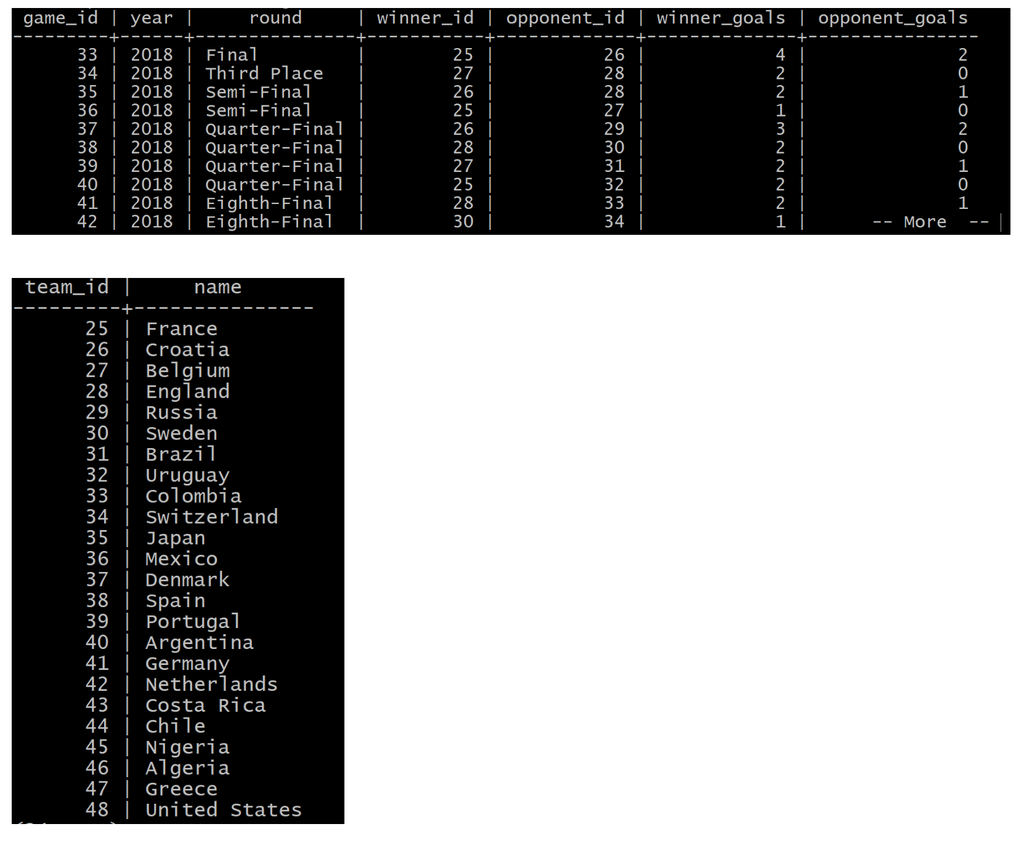

## Answering Some Questions

We can run some queries to learn more about the database using a Bash script. Similar to the script used to insert data, we will start by connecting with a `.env` file and creating a `PSQL` variable.

```
set -o allexport
source .env
set +o allexport

PSQL="psql -t --no-align -c"
```

Next, we will use the `PSQL` variable to write some queries that will help us explore the data.

```
echo -e "\nTotal number of goals in all games from winning teams:"
echo "$($PSQL "SELECT SUM(winner_goals) FROM games")"

echo -e "\nTotal number of goals in all games from both teams combined:"
echo "$($PSQL "select sum(winner_goals + opponent_goals) from games")"

echo -e "\nAverage number of goals in all games from the winning teams:"
echo "$($PSQL "select avg(winner_goals) from games")"

echo -e "\nAverage number of goals in all games from the winning teams rounded to two decimal places:"
echo "$($PSQL "select round(avg(winner_goals), 2) from games")"

echo -e "\nAverage number of goals in all games from both teams:"
echo "$($PSQL "select avg(winner_goals + opponent_goals) from games")"

echo -e "\nMost goals scored in a single game by one team:"
echo "$($PSQL "select max(winner_goals) from games")"

echo -e "\nNumber of games where the winning team scored more than two goals:"
echo "$($PSQL "select count(*) from games where winner_goals > 2")"

echo -e "\nWinner of the 2018 tournament team name:"
echo "$($PSQL "select name from teams left join games on teams.team_id = games.winner_id where year=2018 AND round='Final'")"

echo -e "\nList of teams who played in the 2014 'Eighth-Final' round:"
echo "$($PSQL "select name from teams inner join games on teams.team_id = games.winner_id where year=2014 and round='Eighth-Final' union select name from teams inner join games on teams.team_id = games.opponent_id where year=2014 and round='Eighth-Final' order by name")"

echo -e "\nList of unique winning team names in the whole data set:"
echo "$($PSQL "select distinct(name) from teams inner join games on teams.team_id = games.winner_id order by name")"

echo -e "\nYear and team name of all the champions:"
echo "$($PSQL "select year, name from games inner join teams on games.winner_id = teams.team_id where round = 'Final' order by year")"

echo -e "\nList of teams that start with 'Co':"
echo "$($PSQL "select name from teams where name LIKE 'Co%' order by name")"
```

Let's take a look at the results:

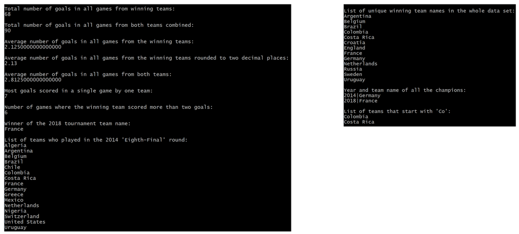

## Reflection

This is a good start to getting to know the data. As someone who doesn't follow soccer as much, it's surprising to see how difficult it is to score. Additionally, the geographic concentration of winning teams makes it apparent that Europe and South America are big soccer regions. It would be interesting to add data from other world cups and analyze if scoring patterns or regional concentrations of winning teams has stayed the same throughout history. Furthermore, we could look at different aspects (i.e. winning goals, championships won) of specific teams through time.